## Reproducible Research - Peer Assessment 1

The assignment had five parts, each with multiple questions. The questions are included in the report below, along with their answers.

#### Part 1 - Loading and preprocessing the data

**1. Load the data**

The code below reads the data out of the working directory.

```r
raw.data<-read.csv("activity.csv")
```

**2. Process/transform the data**

The code below creates an index of complete cases, and then produces a dataframe with only those data.

```r
complete.index<-complete.cases(raw.data)
complete.data<-raw.data[complete.index,,]
```

#### Part 2 - What is mean total number of steps taken per day?

**1. Calculate the total number of steps taken per day**

The code below calculates the mean number of steps for each day.

```r
daily.means<-tapply(
    complete.data$steps,complete.data$date,mean)
```

**2. Make a histogram of the total number of steps taken each day.**

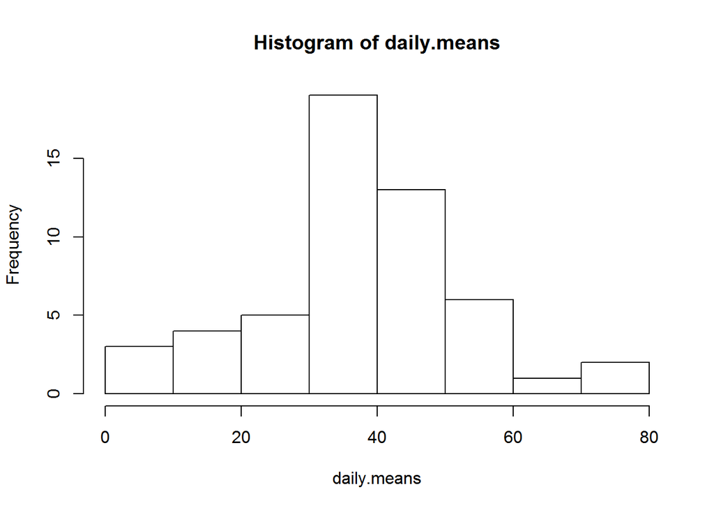

```r
hist(daily.means)
```

```r
complete.mean<-mean(daily.means, na.rm=TRUE)
complete.median<-median(daily.means, na.rm=TRUE)
```

#### Part 3 - What is the average daily activity pattern?

**1. Make a time series plot of the 5-minute interval and the average number of steps taken, averaged across all days.**

The code below generates a time series plot of the 5-minute interval averages

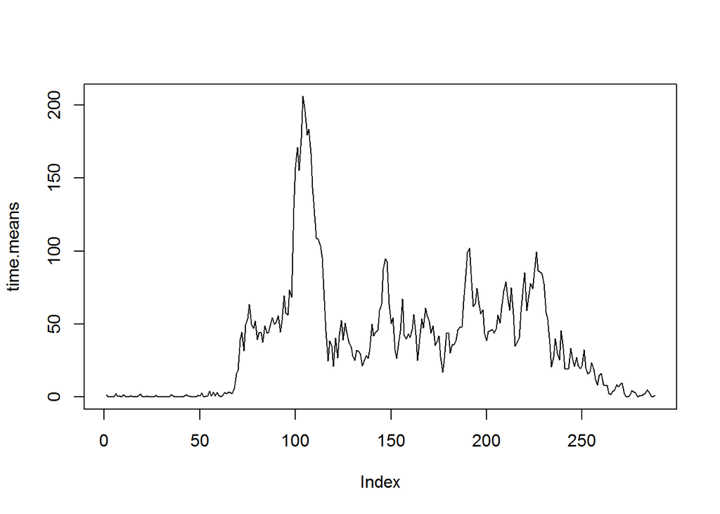

```r
time.means<-tapply(
    complete.data$steps,complete.data$interval,mean)
plot(time.means, type="l")
```

The code below calculates which 5-minute interval contains, on average, the maximum number of steps.

```r
time.means.df<-as.data.frame(time.means)
names<-as.vector(dimnames(time.means.df)[[1]])
time.means.df$time.means<-as.vector(
    time.means.df$time.means)
time.means.df$interval<-names
five.minute.max<-time.means.df[which.max(time.means.df$time.means),]
```

#### Part 4 - Imputing missing values

**1. Calculate and report the total number of missing values in the dataset.**

The code below calculates the total number of missing values.

```r
index.summary<-summary(complete.index)
```

The raw data contains **2304** missing values. *Bold values calculated live and reported inline.*

**2. Devise a strategy for filling in all of the missing values in the dataset.**

The missing values were replaced with the average number of steps for that 5-minute interval across all days.

**3. Create a new dataset that is equal to the original dataset but with the missing data filled in.**

The code below creates a new dataset with the missing data filled in using the strategy discussed in Part 4 - Question 2.

```r
time.means.df$interval<-as.numeric(time.means.df$interval)
raw.data$means<-time.means.df$time.means
impute.data<-raw.data
for(i in seq_along(impute.data$steps)) if(is.na(impute.data$steps[i])==TRUE)
    impute.data$steps[i]<-impute.data$means[i]
impute.daily.means<-tapply(
    impute.data$steps,impute.data$date,mean)
```

**4.1 Make a histogram of the total number of steps taken each day.**

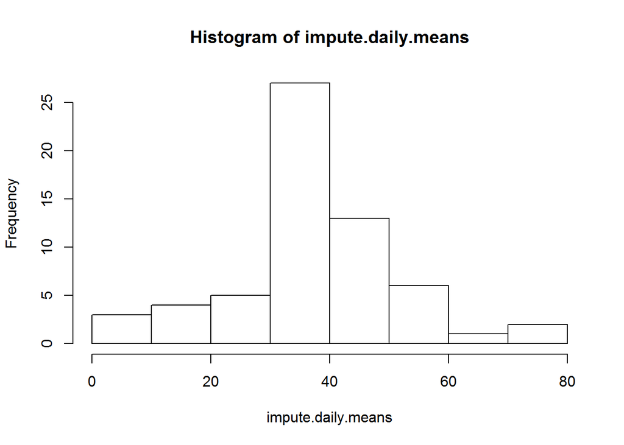

```r
hist(impute.daily.means)
```

```r
impute.mean<-mean(impute.daily.means)
impute.median<-median(impute.daily.means)
```

**4.3 Do these values differ from the estimates from the first part of the assignment?**

The mean with imputed data is **0** steps different than the mean with non-imputed data. *Bold values calculated live and reported inline.*

The median with imputed data is **0.0041274** steps different than the median with non-imputed data. *Bold values calculated live and reported inline.*

**4.4 What is the impact of imputing missing data on the estimates of the total daily number of steps?**

Imputing missing data, had a very minor impact on the estimates of total daily number of steps.

#### Part 5 - Are there differences in activity patterns between weekdays and weekends?

**1. Create a new factor variable in the dataset with two levels - “weekday” and “weekend” indicating whether a given date is a weekday or weekend day.**

The code below creates a new factor variable, impute.data$weekday, indicating if a given date is a weekday or weekend day.

```r
impute.data$date<-as.POSIXct(impute.data$date)
impute.data$weekday<-weekdays(impute.data$date)

impute.data$weekday<-sub("Monday","Weekday",impute.data$weekday)
impute.data$weekday<-sub("Tuesday","Weekday",impute.data$weekday)
impute.data$weekday<-sub("Wednesday","Weekday",impute.data$weekday)
impute.data$weekday<-sub("Thursday","Weekday",impute.data$weekday)
impute.data$weekday<-sub("Friday","Weekday",impute.data$weekday)
impute.data$weekday<-sub("Saturday","Weekend",impute.data$weekday)
impute.data$weekday<-sub("Sunday","Weekend",impute.data$weekday)
impute.data$weekday<-as.factor(impute.data$weekday)
```

**2. Make a panel plot containing a time series plot of the 5-minute interval and the average number of steps taken, averaged across all weekday days or weekend days.**

The code below creates a panel plot containing a time series plot of the 5-minute interval and average number of steps averaged across all weekday days or weekend days.

```r
require(lattice)
```

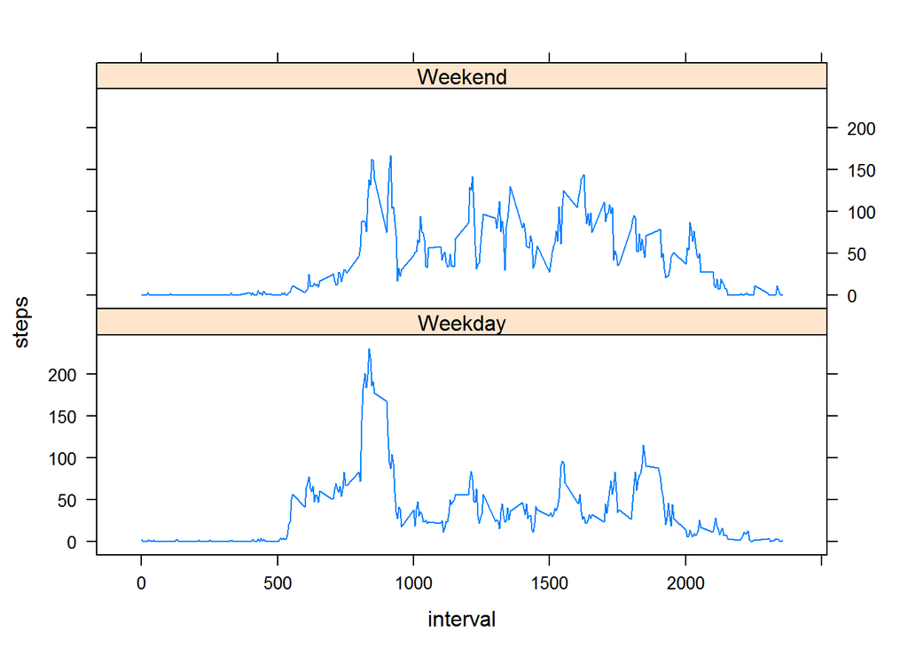

```r
weekday.data<-aggregate(steps ~ interval + weekday, data = impute.data, mean)
xyplot(steps~interval|weekday, data=weekday.data, type="l", layout=c(1,2))
```

**End of Assignment**